# Machine Learning with R.

Real estate market in Switzerland in 2018.

Tomasz Bielaczyc

Our goal is to see how the features like location, number of rooms or date of built can be used  
to predict the price of house or apartment. We will compare a couple of machine learning tools.

## 1. From raw to useful data.

We have three files of data downloaded using Web Scraper from [home.ch](https://www.home.ch/en/).

```r
be <- read_csv("bern_home.csv")                               #library(tidyverse)
gr <- read_csv("graubuenden_home.csv")
zh <- read_csv("zurich_home.csv")
```

We add the information about canton (which will be useful for visualization). Then we join three sets of data.

```r
be$canton <- "BE"; gr$canton <- "GR"; zh$canton <- "ZH"

BEGRZH <- (zh %>% full_join(gr)) %>% full_join(be)

glimpse(BEGRZH)                                               #Let's take a quit look at the data.
```

```
## Rows: 2,305
## Columns: 11
## $ `web-scraper-order`     <chr> "1526593240-2649", "1526590981-2167", "1526592178-2403", "1526594259-3032",…
## $ `web-scraper-start-url` <chr> "https://www.home.ch/en/buy/f/canton-zurich/?pageNum=10&view=list", "https:…
## $ Zurich_home             <chr> "Schlossblick Grüningen, 4,5-Zimmerwohnung\n            \n            \n   …
## $ `Zurich_home-href`      <chr> "https://www.home.ch/en/buy/detail/apartment/subcategory-flat/at-Gr%C3%BCni…
## $ category                <chr> "Apartment", "Apartment", "Attic flat", "Apartment", "Apartment", "Single h…
## $ `year built`            <chr> "2019", "4.5", "2016", "2018", "1995", "6.5", "1964", "2018", "1883", "2018…
## $ where                   <dbl> 8627, 8483, 8002, 8105, 8405, 8332, 8824, 8038, 8493, 8820, 8421, 8108, 861…
## $ rooms                   <chr> "4.5", "145 m2", "4.5", "2.5", "2.5", "228 m2", "8.5", "3.5", "16", "5.5", …
## $ `living space`          <chr> "112 m2", "null", "145 m2", "91 m2", "71 m2", "330 m2", "212 m2", "101 m2",…
## $ price                   <chr> "955'000", "738'000", "3'200'000", "695'000", "485'000", "2'450'000", "2'45…
## $ canton                  <chr> "ZH", "ZH", "ZH", "ZH", "ZH", "ZH", "ZH", "ZH", "ZH", "ZH", "ZH", "ZH", "ZH…
```

Our data are a bit messy. We have to prepare them for further use.

```r
BEGRZH <- BEGRZH %>%
  select(category:canton) %>%                                 #We don't need some columns
  rename(year = `year built`, space = `living space`)         #and we don't want two-word col-names.

BEGRZH <- BEGRZH %>%
  mutate(year = as.numeric(year)) %>%                         #We want "year" to be a number,
  filter(!is.na(year))                                        #we remove NA created in this way.

BEGRZH <- BEGRZH %>%
  mutate(rooms = as.numeric(rooms)) %>%                       #We do the same with "rooms".
  filter(!is.na(rooms))

BEGRZH <- BEGRZH %>%
  filter(str_detect(space, "m2$")) %>%                        #Remove "m2" from end of "space".
  mutate(space = as.numeric(str_replace(space, " m2", "")))

BEGRZH <- BEGRZH %>%
  filter(!str_detect(price, "^P")) %>%                        #Remove rows with 'Price for request'
  mutate(price = as.numeric(str_replace_all(price, "'", ""))) #and adjust formatting of numbers.

glimpse(BEGRZH)
```

```
## Rows: 1,427
## Columns: 7
## $ category <chr> "Apartment", "Attic flat", "Apartment", "Apartment", "Single house", "Apartment", "Single …
## $ year     <dbl> 2019, 2016, 2018, 1995, 1964, 2018, 1883, 2018, 2017, 2017, 2018, 2018, 2009, 2019, 1998, …
## $ where    <dbl> 8627, 8002, 8105, 8405, 8824, 8038, 8493, 8820, 8108, 8614, 8117, 8955, 8197, 8635, 8155, …
## $ rooms    <dbl> 4.5, 4.5, 2.5, 2.5, 8.5, 3.5, 16.0, 5.5, 4.5, 6.5, 2.5, 5.5, 3.5, 3.5, 3.5, 2.5, 4.5, 3.5,…
## $ space    <dbl> 112, 145, 91, 71, 212, 101, 370, 119, 103, 155, 65, 165, 140, 94, 96, 118, 127, 134, 161, …
## $ price    <dbl> 955000, 3200000, 695000, 485000, 2450000, 1390000, 1750000, 1580000, 770000, 1750000, 6500…
## $ canton   <chr> "ZH", "ZH", "ZH", "ZH", "ZH", "ZH", "ZH", "ZH", "ZH", "ZH", "ZH", "ZH", "ZH", "ZH", "ZH", …
```

After looking at the drawings…

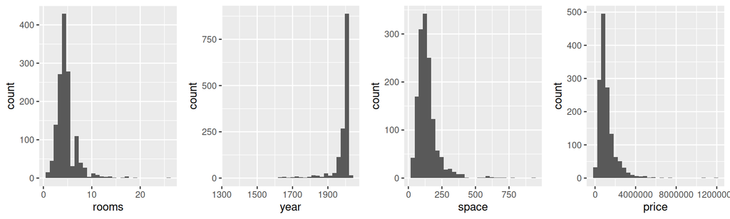

```r
grid.arrange(
  ggplot(BEGRZH, aes(rooms)) + geom_histogram(),
  ggplot(BEGRZH, aes(year)) + geom_histogram(),
  BEGRZH %>% filter(space < 1000) %>% ggplot() + geom_histogram(aes(space)),
  ggplot(BEGRZH, aes(price)) + geom_histogram(),
  ncol = 4)
```

…we are willing to get rid of rare values.

```r
BEGRZH <- BEGRZH %>%
  filter (rooms < 9, year > 1945, space < 400, price < 3.5e+06)
```

Moreover…

```r
cat_sub <- BEGRZH %>%
  group_by(category) %>%
  summarise(numb = n()) %>%
  arrange(desc(numb)) %>%
  filter(numb >= 50)
```

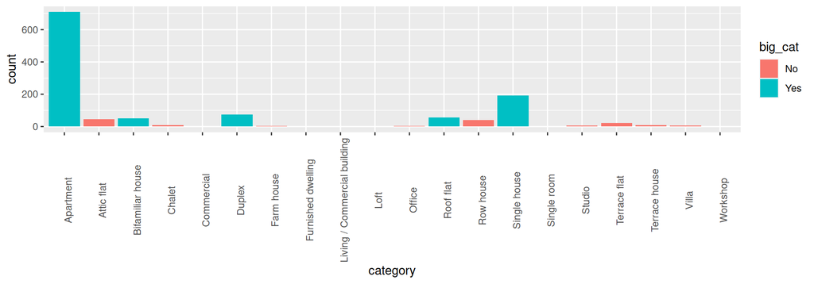

```r
BEGRZH %>%
  mutate(big_cat = ifelse(category %in% cat_sub$category, "Yes", "No")) %>%
  ggplot(aes(category, fill = big_cat)) +
  geom_bar() + theme(axis.text.x = element_text(angle = 90))
```

…we will only consider popular categories.

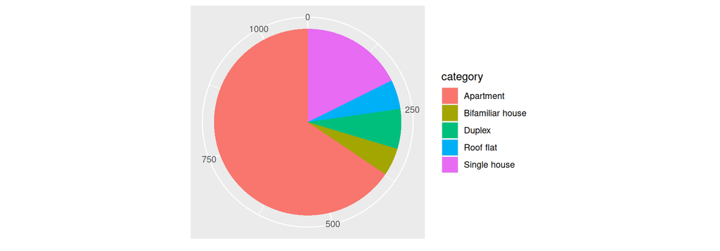

```r
BEGRZH <- BEGRZH %>%
  filter(category %in% cat_sub$category)                      #We leave only popular categories.

ggplot(BEGRZH, aes(x = factor(1), fill = category)) +
  geom_bar(width = 1) +
  coord_polar(theta = "y") +
    theme(axis.ticks = element_blank(),
          axis.title = element_blank(),
          axis.text.y = element_blank())                      #Let's see the proportions now.
```

```r
nrow(BEGRZH)                                                  #how many rows (examples) are left
```

```
## [1] 1083
```

## 2. Data visualisation

We can visualize our data in many different ways.

### Price / size, canton.

Of course the price depends on the size of the flat. Let’s have a look.

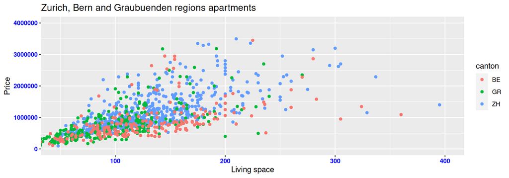

```r
BEGRZH %>%
  ggplot(aes(space, price, color = canton)) +
  coord_cartesian(xlim = c(50, 400),
                  ylim = c(0, 4e+06)) +
  theme(axis.text.x = element_text(face = "bold", color = "blue"),
        axis.text.y = element_text(face = "bold", color = "blue")) +
  labs(title = "Zurich, Bern and Graubuenden regions apartments",
           x = "Living space",
           y = "Price") +
  geom_point()
```

### Price / rooms, category.

Similarly prices depend of the number of rooms. By the way let’s see the differences among different categories.

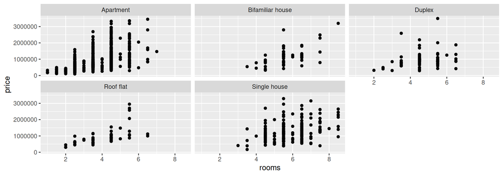

```r
ggplot(data = BEGRZH) +
  geom_point(mapping = aes(x = rooms, y = price)) +
  facet_wrap(~ category, nrow = 2)
```

### Mean prices

Let’s draw mean price in every category. Let’s also see if the prices strongly depend of the decade of built.

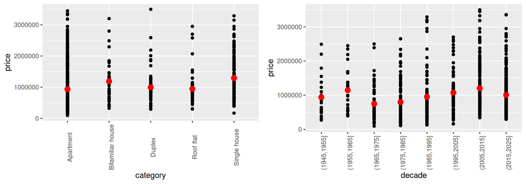

```r
cat_price <- BEGRZH %>%
  group_by(category) %>%
  transmute(av_pr = mean(price))

plot_cat_price <-
  ggplot(BEGRZH, aes(x = category)) +
  geom_point(aes(y = price)) +
  geom_point(data = cat_price, aes(y = av_pr), colour = "red", size = 3) +
  theme(axis.text.x = element_text(angle = 90))

dec_price <- BEGRZH %>%
  mutate(decade = cut(year, breaks = seq(from = 1945, to = 2025, by = 10))) %>%
  group_by(decade) %>%
  summarise(av_pr = mean(price))

plot_dec_price <-
  ((BEGRZH %>% mutate(decade = cut(year, breaks = seq(from = 1945, to = 2025, by = 10)))) %>%
  full_join(dec_price, by = "decade")) %>%
  ggplot(aes(x = decade)) +
  geom_point(aes(y = price)) +
  geom_point(aes(y = av_pr), colour = "red", size = 3) +
  theme(axis.text.x = element_text(angle = 90))

grid.arrange(plot_cat_price, plot_dec_price, ncol=2)
```

### Map

Let’s see the location of the apartments on the map.

```r
ch_postal <- read_csv("ch_postal_codes.csv")
ch_postal <- ch_postal %>%                                    #Add Latitude
  select(`Postal Code`, Latitude, Longitude)                  #and Longitude to the table.

BEGRZH <- BEGRZH %>%
  left_join(ch_postal, c("where" = "Postal Code"))

leaflet(BEGRZH) %>%                                           #Use openstreetmap.
  addTiles() %>%
  addMarkers(lng = ~Longitude,
             lat = ~Latitude,
             label = ~as.character(where),
             clusterOptions = markerClusterOptions()
             )
```

[interactive chart not shown]

## 3. Price predictions - regression models

Now we will see how well we are able to predict housing prices.  
Let’s look at all the data in one table.

```r
datatable(BEGRZH, filter = "top")                             #library(DT)
```

|  | category | year | where | rooms | space | price | canton | Latitude | Longitude |
| --- | --- | --- | --- | --- | --- | --- | --- | --- | --- |
| 1 | Apartment | 2019 | 8627 | 4.5 | 112 | 955000 | ZH | 47.2786 | 8.762 |
| 2 | Apartment | 2018 | 8105 | 2.5 | 91 | 695000 | ZH | 47.4439 | 8.4855 |
| 3 | Apartment | 1995 | 8405 | 2.5 | 71 | 485000 | ZH | 47.4776 | 8.7783 |
| 4 | Single house | 1964 | 8824 | 8.5 | 212 | 2450000 | ZH | 47.1925 | 8.6407 |
| 5 | Apartment | 2018 | 8038 | 3.5 | 101 | 1390000 | ZH | 47.3416 | 8.5369 |
| 6 | Apartment | 2018 | 8820 | 5.5 | 119 | 1580000 | ZH | 47.223 | 8.6555 |
| 7 | Apartment | 2017 | 8108 | 4.5 | 103 | 770000 | ZH | 47.439 | 8.4324 |
| 8 | Single house | 2017 | 8614 | 6.5 | 155 | 1750000 | ZH | 47.3211 | 8.7583 |
| 9 | Apartment | 2018 | 8117 | 2.5 | 65 | 650000 | ZH | 47.3704 | 8.6434 |
| 10 | Apartment | 2009 | 8197 | 3.5 | 140 | 795000 | ZH | 47.6083 | 8.5448 |

[output cut: 1073 more lines]

If we define non-numeric columns as factors then the “summary” command will display useful informations.

```r
BEGRZH$category <- as.factor(BEGRZH$category)
BEGRZH$canton <- as.factor(BEGRZH$canton)

summary(BEGRZH)
```

```
##              category        year          where          rooms           space           price
##  Apartment       :710   Min.   :1946   Min.   :2500   Min.   :1.000   Min.   : 24.0   Min.   :  95000
##  Bifamiliar house: 52   1st Qu.:1992   1st Qu.:7030   1st Qu.:3.500   1st Qu.: 90.0   1st Qu.: 620000
##  Duplex          : 75   Median :2011   Median :8108   Median :4.500   Median :117.0   Median : 870000
##  Roof flat       : 55   Mean   :2003   Mean   :7159   Mean   :4.374   Mean   :123.8   Mean   :1016166
##  Single house    :191   3rd Qu.:2017   3rd Qu.:8460   3rd Qu.:5.500   3rd Qu.:153.0   3rd Qu.:1250000
##                         Max.   :2020   Max.   :8955   Max.   :8.500   Max.   :395.0   Max.   :3498000
##  canton      Latitude       Longitude
##  BE:225   Min.   :46.20   Min.   : 6.987
##  GR:264   1st Qu.:46.80   1st Qu.: 8.466
##  ZH:594   Median :47.26   Median : 8.638
##           Mean   :47.12   Mean   : 8.650
##           3rd Qu.:47.40   3rd Qu.: 8.872
##           Max.   :47.69   Max.   :10.448
```

After dividing the data into two parts…

```r
set.seed(100)
samp <- sample(1083, 783)                                     #We create random set of indexes
BEGRZH_train <- BEGRZH[samp, ]                                #and divid data in fixed proportions.
BEGRZH_test <- BEGRZH[-samp, ]

summary(BEGRZH_train); summary(BEGRZH_test)
```

```
##              category        year          where          rooms           space           price
##  Apartment       :513   Min.   :1946   Min.   :2500   Min.   :1.000   Min.   : 24.0   Min.   :  95000
##  Bifamiliar house: 39   1st Qu.:1992   1st Qu.:7031   1st Qu.:3.500   1st Qu.: 91.0   1st Qu.: 627000
##  Duplex          : 52   Median :2011   Median :8107   Median :4.500   Median :118.0   Median : 865000
##  Roof flat       : 37   Mean   :2003   Mean   :7166   Mean   :4.389   Mean   :124.7   Mean   :1026575
##  Single house    :142   3rd Qu.:2017   3rd Qu.:8434   3rd Qu.:5.500   3rd Qu.:153.0   3rd Qu.:1250000
##                         Max.   :2020   Max.   :8955   Max.   :8.500   Max.   :395.0   Max.   :3498000
##  canton      Latitude       Longitude
##  BE:161   Min.   :46.20   Min.   : 6.987
##  GR:196   1st Qu.:46.80   1st Qu.: 8.466
##  ZH:426   Median :47.26   Median : 8.638
##           Mean   :47.12   Mean   : 8.656
##           3rd Qu.:47.41   3rd Qu.: 8.918
##           Max.   :47.69   Max.   :10.448
```

```
##              category        year          where          rooms           space            price
##  Apartment       :197   Min.   :1948   Min.   :2515   Min.   :1.000   Min.   : 32.00   Min.   : 165000
##  Bifamiliar house: 13   1st Qu.:1988   1st Qu.:7018   1st Qu.:3.500   1st Qu.: 86.75   1st Qu.: 595000
##  Duplex          : 23   Median :2009   Median :8122   Median :4.500   Median :113.00   Median : 877500
##  Roof flat       : 18   Mean   :2002   Mean   :7141   Mean   :4.335   Mean   :121.42   Mean   : 989000
##  Single house    : 49   3rd Qu.:2017   3rd Qu.:8472   3rd Qu.:5.500   3rd Qu.:154.00   3rd Qu.:1252500
##                         Max.   :2020   Max.   :8955   Max.   :8.500   Max.   :337.00   Max.   :3450000
##  canton      Latitude       Longitude
##  BE: 64   Min.   :46.23   Min.   : 7.109
##  GR: 68   1st Qu.:46.81   1st Qu.: 8.466
##  ZH:168   Median :47.27   Median : 8.637
##           Mean   :47.12   Mean   : 8.637
##           3rd Qu.:47.39   3rd Qu.: 8.848
##           Max.   :47.68   Max.   :10.398
```

…we define a function that compares errors.

```r
AvErr <- function(act, pred) {
  mean(abs(act - pred))
  }
```

The average difference between the average price and the actual price is over 40%. It’s worth to look for a better approximation of prices than the average price.

```r
BEGRZH_test_av = mean(BEGRZH_test$price)
BEGRZH_test_av; AvErr(BEGRZH_test$price, BEGRZH_test_av)
```

```
## [1] 989000
```

```
## [1] 421633.3
```

### a) Linear regression

Let’s start with something basic.

```r
BEGRZH_price_Regr <- lm(price ~ ., data = BEGRZH_train)

summary(BEGRZH_price_Regr)
```

```
##
## Call:
## lm(formula = price ~ ., data = BEGRZH_train)
##
## Residuals:
##      Min       1Q   Median       3Q      Max
## -1931099  -228634   -80618   154446  1803195
##
## Coefficients:
##                             Estimate  Std. Error t value             Pr(>|t|)
## (Intercept)              28849829.65  4682028.27   6.162   0.0000000011586769 ***
## categoryBifamiliar house  -165250.19    74734.84  -2.211              0.02732 *
## categoryDuplex            -134221.68    62187.79  -2.158              0.03121 *
## categoryRoof flat         -105415.42    71476.48  -1.475              0.14067
## categorySingle house      -141175.73    53096.19  -2.659              0.00800 **
## year                         2156.29      921.53   2.340              0.01954 *
## where                         -16.54       40.38  -0.410              0.68219
## rooms                        8689.91    21047.97   0.413              0.67982
## space                        8057.51      551.28  14.616 < 0.0000000000000002 ***
## cantonGR                  -205889.64   147763.86  -1.393              0.16391
## cantonZH                   588736.54   183228.00   3.213              0.00137 **
## Latitude                  -732630.68    93576.65  -7.829   0.0000000000000162 ***
## Longitude                  142576.26    70835.97   2.013              0.04449 *
## ---
## Signif. codes:  0 '***' 0.001 '**' 0.01 '*' 0.05 '.' 0.1 ' ' 1
##
## Residual standard error: 416700 on 770 degrees of freedom
## Multiple R-squared:  0.5141, Adjusted R-squared:  0.5065
## F-statistic: 67.89 on 12 and 770 DF,  p-value: < 0.00000000000000022
```

We can see how this tool coped with non-numeric data (dividing them into parts). The p-value is small, so the model is in small extent accidental. The R-squared says that model explains the price value in about fifty percent.  
Let’s apply this model for the test data…

```r
BEGRZH_test_Regr <- predict(BEGRZH_price_Regr, BEGRZH_test)
```

…and see the correlation between predicted and real price and the average error.

```r
cor(BEGRZH_test$price, BEGRZH_test_Regr)
```

```
## [1] 0.7345268
```

```r
AvErr(BEGRZH_test$price, BEGRZH_test_Regr)
```

```
## [1] 273977.7
```

### b) Support Vector Machines

This very nice mathematical concept relies on finding hyperplanes that distinctly classify the data points.

```r
BEGRZH_price_SVM <- ksvm(price ~ ., data = BEGRZH_train)      #library(kernlab)
BEGRZH_test_SVM <- predict(BEGRZH_price_SVM, BEGRZH_test)

cor(BEGRZH_test$price, BEGRZH_test_SVM)
```

```
##          [,1]
## [1,] 0.795718
```

```r
AvErr(BEGRZH_test$price, BEGRZH_test_SVM)
```

```
## [1] 220951.5
```

Of course SVM gave us a better result then regression algorithm.

### c) Random Forest

The name is quite appropriate: we take a bunch of decision trees to create the forest.

```r
BEGRZH_price_RF <- randomForest(price ~ .,
                                data = BEGRZH_train,
                                ntree = 50,
                                mtry = 5)                     #library(randomForest)
BEGRZH_test_RF <- predict(BEGRZH_price_RF, BEGRZH_test)

cor(BEGRZH_test$price, BEGRZH_test_RF)
```

```
## [1] 0.8547799
```

```r
AvErr(BEGRZH_test$price, BEGRZH_test_RF)
```

```
## [1] 192799.6
```

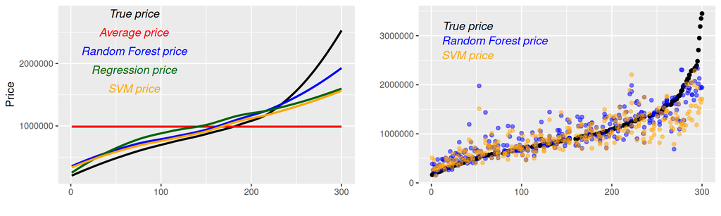

```r
t <- tibble("True price" = BEGRZH_test$price,
            "Average price" = BEGRZH_test_av,
            "Regr price" = BEGRZH_test_Regr,
            "SVM price" = as.vector(BEGRZH_test_SVM),
            "Forest price" = as.vector(BEGRZH_test_RF));

t <- t %>%
  arrange(`True price`) %>%
  mutate(nr = min_rank(`True price`))

grid.arrange(
t %>%
  ggplot() +
  geom_smooth(se = FALSE, aes(x = nr, y = `True price`), color = "black") +
  geom_smooth(se = FALSE, aes(x = nr, y = `Average price`), color = "red") +
  geom_smooth(se = FALSE, aes(x = nr, y = `Forest price`), color = "blue", alpha = 0.5) +
  geom_smooth(se = FALSE, aes(x = nr, y = `Regr price`), color = "darkgreen", alpha = 0.3) +
  geom_smooth(se = FALSE, aes(x = nr, y = `SVM price`), color = "orange", alpha = 0.3) +
  labs(x = "", y = "Price") +
  annotate("text", x = 70, y = 2.8e+06, label = "True price", size = 4, fontface = "italic", color = "black") +
  annotate("text", x = 70, y = 2.5e+06, label = "Average price", size = 4, fontface = "italic", color = "red") +
  annotate("text", x = 70, y = 2.2e+06, label = "Random Forest price", size = 4, fontface = "italic", color = "blue") +
  annotate("text", x = 70, y = 1.9e+06, label = "Regression price", size = 4, fontface = "italic", color = "darkgreen") +
  annotate("text", x = 70, y = 1.6e+06, label = "SVM price", size = 4, fontface = "italic", color = "orange"),
t %>%
  ggplot() +
  geom_point(aes(x = nr, y = `True price`), color = "black") +
  geom_point( aes(x = nr, y = `Forest price`), color = "blue", alpha = 0.5) +
  geom_point(aes(x = nr, y = `SVM price`), color = "orange", alpha = 0.5)+
  labs(x = "", y = "") +
  annotate("text", x = 40, y = 3.2e+06, label = "True price", size = 4, fontface = "italic", color = "black") +
  annotate("text", x = 70, y = 2.9e+06, label = "Random Forest price", size = 4, fontface = "italic", color = "blue") +
  annotate("text", x = 40, y = 2.6e+06, label = "SVM price", size = 4, fontface = "italic", color = "orange"),
ncol=2)
```

## 4. Principal Component Analysis

Let’s try to reduce the number of features.

### Manual approach

First we just look at the features and decide which are the least useful. Since Latitude and Longitude give us the exact locations it seems reasonable to omit “where” and “canton”. I’m also just guessing that the category is not that important.

```r
BEGRZH_price_RF2 <- randomForest(price ~ .,
                                data = BEGRZH_train[, -c(1, 3, 7)],
                                ntree = 50,
                                mtry = 5)
BEGRZH_test_RF2 <- predict(BEGRZH_price_RF2, BEGRZH_test[, -c(1, 3, 7)])

str(BEGRZH_train[, -c(1, 3, 7)])
```

```
## tibble [783 × 6] (S3: tbl_df/tbl/data.frame)
##  $ year     : num [1:783] 1972 2017 1979 2002 2017 ...
##  $ rooms    : num [1:783] 6.5 4.5 3.5 6.5 5 3.5 4.5 5.5 3.5 4.5 ...
##  $ space    : num [1:783] 190 110 86 154 135 114 83 130 80 115 ...
##  $ price    : num [1:783] 1720000 765000 370000 865000 1120000 790000 695000 575000 740000 595000 ...
##  $ Latitude : num [1:783] 47.2 46.7 46.9 47.1 47.3 ...
##  $ Longitude: num [1:783] 8.53 7.7 7.54 7.09 8.46 ...
```

```r
cor(BEGRZH_test$price, BEGRZH_test_RF2); AvErr(BEGRZH_test$price, BEGRZH_test_RF2)
```

```
## [1] 0.8155748
```

```
## [1] 217930.1
```

We see that the result is not much worse.

### PCA

Now let’s reduce the number of considered features using PCA algorithm. We need numerical data for that.

```r
BEGRZH_n <- as.data.frame(BEGRZH)
BEGRZH_n <- dummy.data.frame(BEGRZH_n,
                             names = c("category",
                                       "canton"))             #library(dummies)
BEGRZH_n <- BEGRZH_n %>%  rename(cat_Apart = categoryApartment,
                                 cat_Bifam = `categoryBifamiliar house`,
                                 cat_Dup = categoryDuplex,
                                 cat_Sing = `categorySingle house`,
                                 cat_Roof = `categoryRoof flat`)

BEGRZH_n_train <- BEGRZH_n[samp, ]
BEGRZH_n_test <- BEGRZH_n[-samp, ]
```

Let’s now rotate our data.

```r
BEGRZH_PCA <- prcomp(BEGRZH_n_train[, -10], scale. = T)       #new 14 features (excluding price)

round(BEGRZH_PCA$rotation, digits = 2)
```

```
##             PC1   PC2   PC3   PC4   PC5   PC6   PC7   PC8   PC9  PC10  PC11  PC12  PC13 PC14
## cat_Apart  0.14 -0.37 -0.30  0.39 -0.05  0.01 -0.11  0.39  0.03  0.05  0.00 -0.01 -0.65 0.04
## cat_Bifam -0.07  0.14  0.04 -0.14 -0.79 -0.40  0.18 -0.21 -0.02  0.02  0.00  0.00 -0.30 0.02
## cat_Dup   -0.07  0.05  0.07 -0.57 -0.15  0.72 -0.09  0.06 -0.01  0.01  0.00  0.00 -0.34 0.02
## cat_Roof  -0.02  0.01  0.04 -0.60  0.44 -0.55  0.01  0.22  0.02 -0.02  0.00 -0.01 -0.29 0.02
## cat_Sing  -0.08  0.35  0.29  0.30  0.36  0.06  0.08 -0.53 -0.03 -0.06  0.01  0.01 -0.53 0.03
## year      -0.06 -0.16 -0.21 -0.09 -0.04 -0.12 -0.84 -0.42  0.09 -0.10  0.02  0.02  0.00 0.00
## where     -0.44 -0.30  0.16  0.03  0.00  0.00  0.05  0.00 -0.15 -0.21  0.02 -0.79  0.00 0.00
## rooms     -0.19  0.39  0.25  0.15 -0.11 -0.02 -0.23  0.41  0.56 -0.43  0.03  0.02  0.00 0.00
## space     -0.22  0.36  0.21  0.13 -0.06 -0.07 -0.39  0.34 -0.53  0.44 -0.04 -0.01  0.00 0.00
## cantonBE   0.35  0.35 -0.28 -0.02  0.01  0.01 -0.03  0.01  0.01  0.04  0.50 -0.39  0.03 0.52
## cantonGR   0.26 -0.24  0.49  0.00 -0.04 -0.03 -0.09 -0.03  0.23  0.26 -0.43 -0.08  0.03 0.56
## cantonZH  -0.51 -0.08 -0.20  0.02  0.03  0.01  0.11  0.02 -0.21 -0.26 -0.03  0.39  0.04 0.64
## Latitude  -0.47  0.03 -0.25  0.01  0.07  0.02  0.10 -0.07  0.52  0.64  0.07 -0.06  0.00 0.00
## Longitude -0.06 -0.37  0.47  0.02 -0.04 -0.02 -0.04  0.01  0.02  0.10  0.75  0.25  0.00 0.00
```

```r
dim(BEGRZH_PCA$x)
```

```
## [1] 783  14
```

### Using the after-PCA data

We create BEGRZH_PCA_train and BEGRZH_PCA_test using the same transformation.

```r
BEGRZH_PCA_train <- as.data.frame(BEGRZH_PCA$x)
BEGRZH_PCA_test <- as.data.frame(predict(BEGRZH_PCA, newdata = BEGRZH_n_test))

BEGRZH_PCA_train <-  data.frame(price = BEGRZH_n_train[ , 10], BEGRZH_PCA_train)
BEGRZH_PCA_test <-  data.frame(price = BEGRZH_n_test[ , 10], BEGRZH_PCA_test)
```

Let’s try random forest for all the new data.

```r
BEGRZH_price_RF3 <- randomForest(price ~ .,
                                 data = BEGRZH_PCA_train,
                                 ntree = 50,
                                 mtry = 5)
BEGRZH_test_RF3_Pred <- predict(BEGRZH_price_RF3, BEGRZH_PCA_test)

cor(BEGRZH_test_RF3_Pred, BEGRZH_PCA_test$price); AvErr(BEGRZH_test_RF3_Pred, BEGRZH_PCA_test$price)
```

```
## [1] 0.7976449
```

```
## [1] 232284.8
```

We can see that our transformation already made it worse. Now, let’s figure out how much data we should consider.

```r
BEGRZH_PCA$sdev                                               #standard deviation of every component
```

```
##  [1] 1.804801410091772861932 1.796877017446439239734 1.507935447689756403022 1.095723827699184749207
##  [5] 1.033936326374979008946 1.030927088944531444525 0.981154663127507764564 0.729984223637392459771
##  [9] 0.415296465140574500019 0.379675642764913667815 0.265534411935868519539 0.157908620009695771502
## [13] 0.000000000000007918302 0.000000000000002131648
```

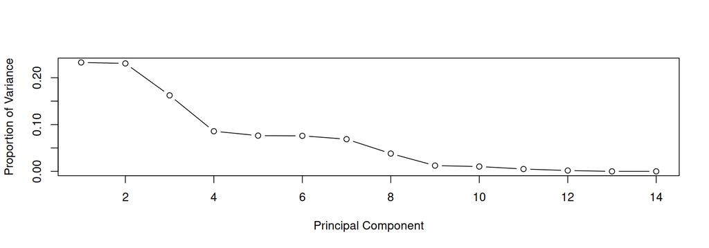

```r
BEGRZH_PCA_train_var <- (BEGRZH_PCA$sdev)^2
BEGRZH_PCA_prop_var <- BEGRZH_PCA_train_var/sum(BEGRZH_PCA_train_var)

plot(BEGRZH_PCA_prop_var,
     xlab = "Principal Component",
     ylab = "Proportion of Variance",
     type = "b")
```

We can see that starting from the ninth feature, they do not vary too much. Hence they don’t give too much information.

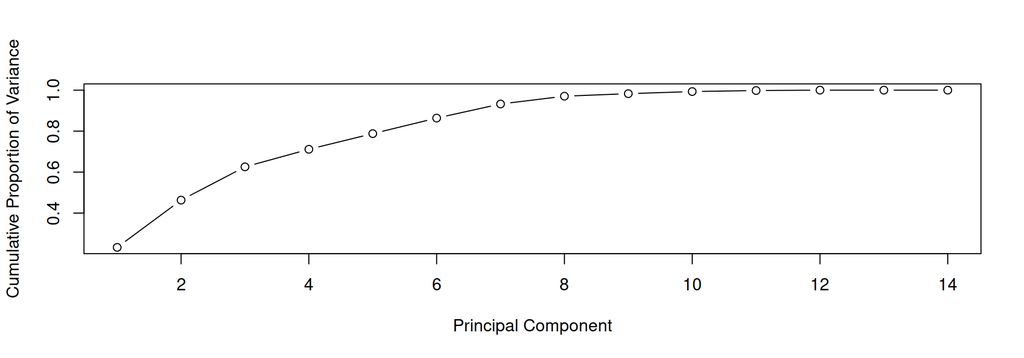

```r
plot(cumsum(BEGRZH_PCA_prop_var), xlab = "Principal Component",
     ylab = "Cumulative Proportion of Variance",
     type = "b")                                              #cumulative scree plot
```

Let’s get rid of the last six. PCA is a great tool when we have a lot of features (and we don’t fully understand them), but apparently it’s not always useful.

```r
BEGRZH_price_RF4 <- randomForest(price ~ .,
                                 data = BEGRZH_PCA_train[ , 1:9],
                                 ntree = 50,
                                 mtry = 5)
BEGRZH_test_RF4_Pred <- predict(BEGRZH_price_RF4, BEGRZH_PCA_test)

cor(BEGRZH_test_RF4_Pred, BEGRZH_PCA_test$price); AvErr(BEGRZH_test_RF4_Pred, BEGRZH_PCA_test$price)
```

```
## [1] 0.7357858
```

```
## [1] 266376.1
```

## 5. Category predictions - classyfication models

Our last goal is to recognize if the category is “Apartment” or not.

```r
BEGRZH_train <- BEGRZH_train %>%
  mutate(category = ifelse(category == "Apartment", 1, 0))
BEGRZH_test <- BEGRZH_test %>%
  mutate(category = ifelse(category == "Apartment", 1, 0))
```

### a) Logical Regression

Once again we start with regression.

```r
BEGRZH_cat_Regr <- glm(category ~ ., data = BEGRZH_train)
BEGRZH_test_Regr <- predict(BEGRZH_cat_Regr, BEGRZH_test)
BEGRZH_test_Regr <- ifelse(BEGRZH_test_Regr > .5, 1, 0)

table(BEGRZH_test$category, BEGRZH_test_Regr, dnn = c('Real', 'Regr-Predicted'))
```

```
##     Regr-Predicted
## Real   0   1
##    0  61  42
##    1  15 182
```

Let’s see how big is the percentige of correct guesses.

```r
100 * sum(BEGRZH_test$category == BEGRZH_test_Regr) / length(BEGRZH_test_Regr)
```

```
## [1] 81
```

### b) Support Vector Machines

If we change “category” to factors the ksvm-functions will recognize that we want classification instead of regression.

```r
BEGRZH_train$category <- as.factor(BEGRZH_train$category)
BEGRZH_test$category <- as.factor(BEGRZH_test$category)

BEGRZH_cat_SVM <- ksvm(category ~ ., data = BEGRZH_train, kernel = "vanilladot")
BEGRZH_test_SVM <- predict(BEGRZH_cat_SVM, BEGRZH_test)

table(BEGRZH_test$category, BEGRZH_test_SVM, dnn = c('Real', 'SVM-Predicted'))
```

```
##     SVM-Predicted
## Real   0   1
##    0  64  39
##    1  17 180
```

```r
100 * sum(BEGRZH_test$category == BEGRZH_test_SVM) / length(BEGRZH_test_SVM)
```

```
## [1] 81.33333
```

### c) Random Forest

Random Forests are also used both for regression and classification.

```r
BEGRZH_cat_RF <- randomForest(category ~ .,
                              data = BEGRZH_train,
                              ntree = 50,
                              mtry = 5)
BEGRZH_test_RF <- predict(BEGRZH_cat_RF, BEGRZH_test)

table(BEGRZH_test$category, BEGRZH_test_RF, dnn = c('Real', 'RF-Predicted'))
```

```
##     RF-Predicted
## Real   0   1
##    0  68  35
##    1  19 178
```

```r
100 * sum(BEGRZH_test$category == BEGRZH_test_RF) / length(BEGRZH_test_RF)
```

```
## [1] 82
```

### d) Entropy Tree

We need data frames to be able to use the Entropy tree algorithm.

```r
BEGRZH_train <- as.data.frame(BEGRZH_train)
BEGRZH_test <- as.data.frame(BEGRZH_test)

BEGRZH_cat_Ent <- C5.0(BEGRZH_train[-1],
                       BEGRZH_train$category,
                       trials = 15)                            #library(C50)
BEGRZH_cat_Ent
```

```
##
## Call:
## C5.0.default(x = BEGRZH_train[-1], y = BEGRZH_train$category, trials = 15)
##
## Classification Tree
## Number of samples: 783
## Number of predictors: 8
##
## Number of boosting iterations: 15
## Average tree size: 40.2
##
## Non-standard options: attempt to group attributes
```

```r
BEGRZH_test_Ent <- predict(BEGRZH_cat_Ent, BEGRZH_test)

table(BEGRZH_test$category, BEGRZH_test_Ent, dnn = c('Real', 'RF-Predicted'))
```

```
##     RF-Predicted
## Real   0   1
##    0  65  38
##    1  22 175
```

```r
round(100 * sum(BEGRZH_test$category == BEGRZH_test_Ent) / length(BEGRZH_test_Ent), 3)
```

```
## [1] 80
```

### e) Nearest Neighbours

Here we will need normalized numerical data.

```r
normalize <- function(x){
  return ((x - min(x)) / (max(x) - min(x)))
  }
BEGRZH_n <- BEGRZH_n %>% select(year:Longitude)
BEGRZH_n <- as.data.frame(lapply(BEGRZH_n, normalize))

BEGRZH_n_train <- BEGRZH_n[samp, ]
BEGRZH_n_test <- BEGRZH_n[-samp, ]

BEGRZH_test_kNN <- knn(train = BEGRZH_n_train,
                      test = BEGRZH_n_test,
                      cl = BEGRZH_train$category,
                      k = 25)                                 #library(kernlab)

table(BEGRZH_test$category, BEGRZH_test_kNN, dnn = c('Real', 'RF-Predicted'))
```

```
##     RF-Predicted
## Real   0   1
##    0  57  46
##    1  11 186
```

```r
round(100 * sum(BEGRZH_test$category == BEGRZH_test_kNN) / length(BEGRZH_test_kNN), 3)
```

```
## [1] 81
```

We can see that though we used very simple model, the answer is very similar to those obtained by much more complicated algorithms.

### f) Neuron Nets

For this model we will also need normalized data.

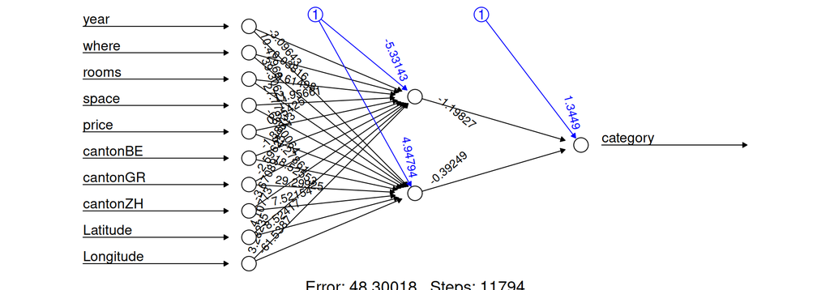

```r
BEGRZH_n_train$category <- (as.numeric(levels(BEGRZH_train$category)[BEGRZH_train$category]))

BEGRZH_test_NN  <- neuralnet(category ~ year + where + rooms + space + price +
                             cantonBE + cantonGR + cantonZH + Latitude + Longitude,
                             data = BEGRZH_n_train, hidden = 2) #library(neuralnet)
plot(BEGRZH_test_NN, rep = "best")
```

```r
BEGRZH_test_NN <- compute(BEGRZH_test_NN, BEGRZH_n_test)
BEGRZH_test_NN <- BEGRZH_test_NN$net.result
BEGRZH_test_NN <- ifelse(BEGRZH_test_NN > .5, 1, 0)

table(BEGRZH_test$category, BEGRZH_test_NN, dnn = c('Real', 'RF-Predicted'))
```

```
##     RF-Predicted
## Real   0   1
##    0  63  40
##    1  18 179
```

```r
round(100 * sum(BEGRZH_test$category == BEGRZH_test_NN) / length(BEGRZH_test_kNN), 3)
```

```
## [1] 80.667
```